# Reproducible Research: Peer Assessment 1

Jerrison Li

## Loading and preprocessing the data

```r
unzipped_data <- unzip(paste0("/Users/jerrison/Coursera_Homework/",
                              "RepData_PeerAssessment1/activity.zip"))

step_data <- read.csv(unzipped_data,
                      stringsAsFactors = FALSE)
```

## What is mean total number of steps taken per day?

1. Calculate the total number of steps taken per day

```r
step_data_by_day <- select(step_data,
                           date,
                           steps) %>%
  group_by(date) %>%
  summarize(steps = sum(steps, na.rm = T))

step_data_by_day
```

```
## # A tibble: 61 x 2
##          date steps
##         <chr> <int>
##  1 2012-10-01     0
##  2 2012-10-02   126
##  3 2012-10-03 11352
##  4 2012-10-04 12116
##  5 2012-10-05 13294
##  6 2012-10-06 15420
##  7 2012-10-07 11015
##  8 2012-10-08     0
##  9 2012-10-09 12811
## 10 2012-10-10  9900
## # ... with 51 more rows
```

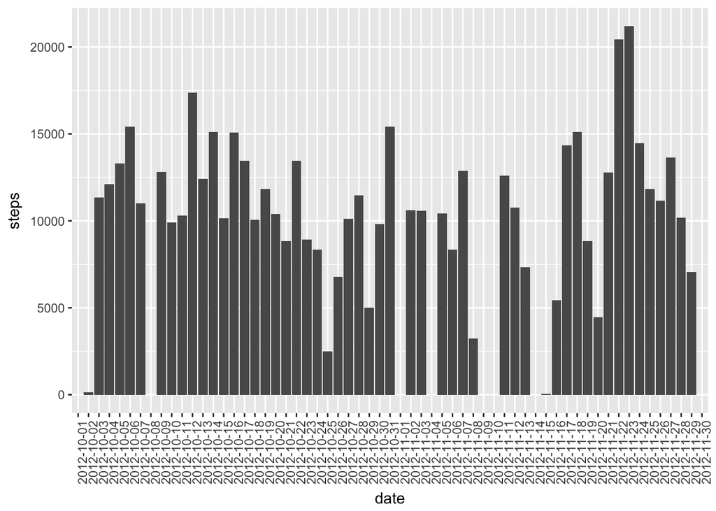

```r
total_steps_per_day_histogram2 <- ggplot(step_data_by_day,
                                        aes(x = date, y = steps)) +
  geom_bar(stat = "identity") +
  theme(axis.text.x = element_text(angle = 90))

total_steps_per_day_histogram2
```

3. Calculate and report the mean and median of the total number of steps taken per day

```r
mean_median_per_day <- select(step_data,
                              date,
                              steps) %>%
  group_by(date) %>%
  summarize(mean_steps = mean(steps, na.rm = T),
            median_steps = median(steps, na.rm = T))

mean_median_per_day
```

```
## # A tibble: 61 x 3
##          date mean_steps median_steps
##         <chr>      <dbl>        <dbl>
##  1 2012-10-01        NaN           NA
##  2 2012-10-02    0.43750            0
##  3 2012-10-03   39.41667            0
##  4 2012-10-04   42.06944            0
##  5 2012-10-05   46.15972            0
##  6 2012-10-06   53.54167            0
##  7 2012-10-07   38.24653            0
##  8 2012-10-08        NaN           NA
##  9 2012-10-09   44.48264            0
## 10 2012-10-10   34.37500            0
## # ... with 51 more rows
```

## What is the average daily activity pattern?

1. Make a time series plot (i.e. 𝚝𝚢𝚙𝚎 = “𝚕”) of the 5-minute interval (x- axis) and the average number of steps taken, averaged across all days (y-axis)

```r
average_steps_per_interval <- select(step_data,
                                     interval,
                                     steps) %>%
  group_by(interval) %>%
  summarize(days_count = n(),
            total_steps = sum(steps, na.rm = T),
            average_steps = sum(steps, na.rm = T)/n())

average_steps_per_interval
```

```
## # A tibble: 288 x 4
##    interval days_count total_steps average_steps
##       <int>      <int>       <int>         <dbl>
##  1        0         61          91    1.49180328
##  2        5         61          18    0.29508197
##  3       10         61           7    0.11475410
##  4       15         61           8    0.13114754
##  5       20         61           4    0.06557377
##  6       25         61         111    1.81967213
##  7       30         61          28    0.45901639
##  8       35         61          46    0.75409836
##  9       40         61           0    0.00000000
## 10       45         61          78    1.27868852
## # ... with 278 more rows
```

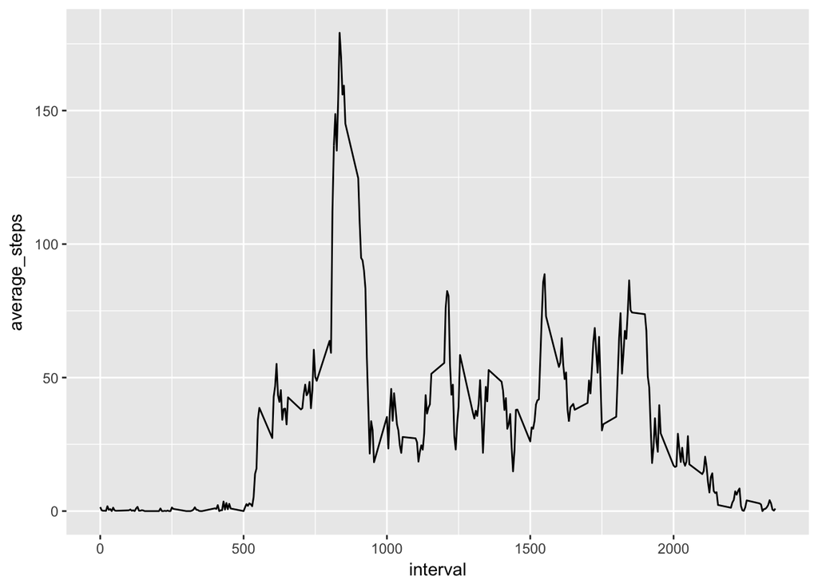

```r
average_steps_per_interval_plot <- ggplot(average_steps_per_interval,
                                          aes(x = interval, y = average_steps)) +
  geom_line()

average_steps_per_interval_plot
```

2. Which 5-minute interval, on average across all the days in the dataset, contains the maximum number of steps?

```r
max_step_interval <- average_steps_per_interval$interval[
  which.max(average_steps_per_interval$average_steps)]
```

Interval 835 contains the maximum number of steps on average.

## Imputing missing values

1. Calculate and report the total number of missing values in the dataset

```r
na_count <- sum(is.na(step_data$steps))
na_count
```

```
## [1] 2304
```

The total number of missing values is 2304.

2. Devise a strategy for filling in all of the missing values in the dataset. The strategy does not need to be sophisticated. For example, you could use the mean/median for that day, or the mean for that 5-minute interval, etc.

My strategy is to use the mean for that 5-minute interval.